# Trapez

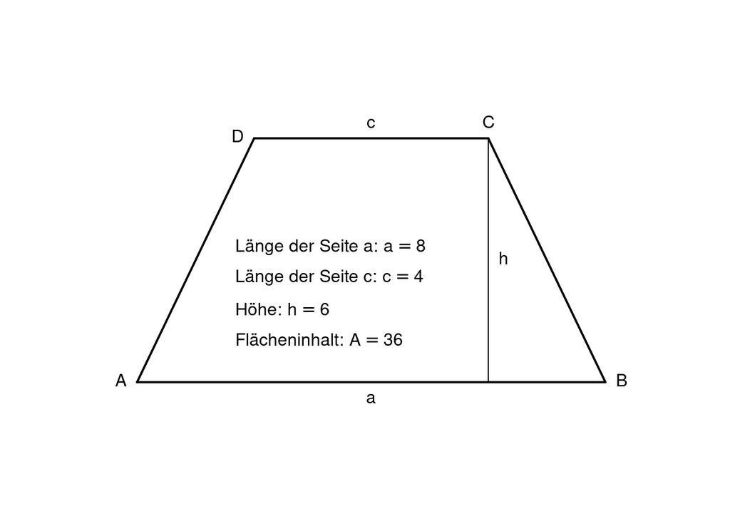

**Flächeninhalt des Trapezes:**

$$A = {(a+c) \cdot h \over 2}$$

**Umfang des Trapezes:**
$$U = a + b + c + d$$

**Was heißt das doch gleich?**

Hier einmal in Worten: Den Flächeninhalt $A$ eines Trapezes erhältst du, indem du die Länge der Höhe $h$ mit der Summe aus der Länge parallelen Seiten a und c multiplizierst und das Ergebnis durch 2 teilst. Auch hier steht die Höhe auf den Seiten a und c senkrecht.

## Aufgaben

Hier geht es zurück zur [**Startseite**](https://gdischinger.github.io/Mathe_8a/03FormelnErstellen/FlächenberechnungErinnerung.html).

### Aufgabe 1

Ein Dreieck habe eine Grundseite $g$ der Länge 4cm und eine zugehörige Höhe $h$ der Länge 6cm. Gib die Höhe eines flächengleichen Trapezes mit den parallelen Seiten $a = 2cm$ und $c = 4cm$ an.

**Gesucht**

Die Länge der Höhe eines Trapezes.

**Gegeben**

Gegeben ist:

1. Ein Dreieck mit der Grundseite $g = 4cm$ und der zugehörige Höhe $h = 6cm$. Dieses Dreieck hat denselben Flächeninhalt wie das Trapez, dessen Höhe gesucht ist.
2. Die Länge der Seite $a$ des Trapezes: $a = 2cm$ und
3. die Länge der zur Seite $a$ parallelen Seite $c$ des Trapezes: $c= 4cm$.

Den Flächeninhalt eines Dreiecks berechnet man folgendermaßen:
$$A = {1 \over 2} \cdot g \cdot h$$

Den Flächeninhalt eines Trapezes berechnet man so:
$$A = {(a+c) \cdot h \over 2}$$

**Vorüberlegung**

Das Trapez hat den gleichen Flächeninhalt wie ein Dreieck mit der Grundseite $g = 4cm$ und der zugehörige Höhe $h = 6cm$.

Dieses Dreieck den Flächeninhalt:
$$A = {1 \over 2} \cdot g \cdot h = {1 \over 2} \cdot 4 cm \cdot 6 cm = 12 cm²$$
Gesucht ist also die Länge der Höhe $h$ eines Trapezes mit Flächeninhalt 12 cm² und den parallelen Seiten $a = 2cm$ und $c = 4cm$.

**Einsetzen**

Nun setzen wir alle bekannten Größen ein, das führt zu:
$$12 cm² = {(2cm + 4 cm) \cdot h \over 2}$$

**Auflösen**

Diese Gleichung muss man nach $h$ auflösen:
$$\begin{align} 12 cm² &= {(2cm + 4 cm) \cdot h \over 2}\\
{}\\
12cm² &= {6cm \cdot h \over 2} \\
{}\\
12cm² &= 3cm \cdot h \quad\quad |:3cm\\
{}\\
4cm &=h\end{align}$$

**Antwort**

Die Höhe eines flächengleichen Trapezes muss also 4 cm lang sein.¸

Hier geht es zurück zur [**Startseite**](https://gdischinger.github.io/Mathe_8a/03FormelnErstellen/FlächenberechnungErinnerung.html).

### Aufgabe 2

Ein Trapez hat den Flächeninhalt 1m². Die Höhe beträgt 20cm. Gib drei verschiedene Möglichkeiten für die Länge der zueinander parallelen Seiten an.

**Gesucht**

Die Längen der parallelen Seiten $a$ und $c$.

**Gegeben**

Gegeben ist:

1. Der Flächeninhalt: $A=1m²$ und
2. die Höhe $h=20cm$

Den Flächeninhalt eines Trapezes berechnet man folgendermaßen:
$$A = {(a+c) \cdot h \over 2}$$

**Einsetzen**

Setzt man nun alle bekannten Größen ein, erhält man folgenden Gleichung:
$$1 m² = {(a+c) \cdot 0,2 m \over 2}$$

**Auflösen**

Diese Gleichung muss man nach $(a+c)$ auflösen:
$$\begin{align}1 m² &= {(a+c) \cdot 0,2 m \over 2} \\
{}\\
1 m² &= (a+c) \cdot 0,1 m \quad\quad\quad |:0,1m\\
{}\\
10 m &=a+c
\end{align}$$

**Antwort**

Daraus ergeben sich zum Beispiel folgende Längen für die Seiten a und c:

1. Möglichkeit: Die Seite a ist einen Meter lang, die Seite c neun Meter (denn 1+9=10)
2. Möglichkeit: Die Seite a ist zwei Meter lang, die Seite c acht Meter (denn 2+8=10)
3. Möglichkeit: Die Seite a ist drei Meter lang, die Seite c sieben Meter (denn 3+7=10)

Hier geht es zurück zur [**Startseite**](https://gdischinger.github.io/Mathe_8a/03FormelnErstellen/FlächenberechnungErinnerung.html).

### Aufgabe 3

Bei einem Trapez beträgt der Flächeninhalt $A=12cm²$ und die Höhe $h=1,5cm$. die zu $a$ parallele Seite $c$ ist dreimal so lang wie $a$. Berechne $a$ und $c$.

**Gesucht**

Die Längen der Seiten $a$ und $c$.

**Gegeben**

Gegeben ist:

1. Der Flächeninhalt: $A=12cm²$ ,
2. die Höhe $h=1,5cm$ und
3. der Hinweis, dass die Seite $c$ dreimal so lang ist wie die Seite $a$, also: $c= 3 \cdot a$.

Den Flächeninhalt eines Trapezes berechnet man folgendermaßen:
$$A = {(a+c) \cdot h \over 2}$$

**Einsetzen**

Setzt man nun alle Angaben ein, erhält man folgenden Gleichung:
$$12 cm² = {(a+3a) \cdot 1,5cm \over 2}$$

**Auflösen**

Diese Gleichung muss man jetzt nach $a$ auflösen:

$$\begin{align}
12 cm² &= {(a+3a) \cdot 1,5cm \over 2}\\
{}\\
12 cm² &= {4a \cdot 1,5 cm \over 2}\\
{}\\
12 cm² &= {a \cdot 6cm \over 2} \\
{}\\
12 cm² &= a \cdot 3cm \quad\quad\quad |:3cm \\
{}\\
4cm &= a \\
{}\\
\Rightarrow a &= 4cm\\
\Rightarrow c &= 3 \cdot a = 3 \cdot 4cm = 12 cm
\end{align}$$

**Antwort**

Die Seite a ist also 4cm lang, die Länge der Seite c beträgt 12cm.

Hier geht es zurück zur [**Startseite**](https://gdischinger.github.io/Mathe_8a/03FormelnErstellen/FlächenberechnungErinnerung.html).

### Aufgabe 4

1. Berechne die Länge der Höhe eines Trapezes mit dem Flächeninhalt $A=24cm²$ und den parallelen Seiten $a=6cm$ und $c=10cm$.
2. Gib an, wie man allgemein die Höhe eines Trapezes mit dem parallelen Seiten $a$ und $c$ berechnen kann, wenn der Flächeninhalt gegeben ist.  
   [Mit anderen Worten: Löse die Formel für den Flächeninhalt eines Trapezes nach h auf!]

**Gesucht**

Gesucht ist die Länge der Höhe $h$ eines Trapezes.

**Gegeben**

Gegeben ist:

1. Der Flächeninhalt: $A=24cm²$,
2. die Seite $a=6cm$ und
3. die dazu parallele Seite $c=10cm$.

Den Flächeninhalt eines Trapezes berechnet man folgendermaßen:
$$A = {(a+c) \cdot h \over 2}$$

**Einsetzen**

Nun setzen wir alle bekannten Größen ein, das führt zu:
$$24 cm² = {(6cm + 10 cm) \cdot h \over 2}$$

**Auflösen**

Diese Gleichung muss man nach $h$ auflösen:
$$\begin{align} 24 cm² &= {(6cm + 10 cm) \cdot h \over 2}\\
{}\\
24cm² &= {16cm \cdot h \over 2} \\
{}\\
24cm² &= 8cm \cdot h \quad\quad |:8cm\\
{}\\
3cm &=h\end{align}$$

**Antwort**

Die Höhe des Trapezes muss also $3cm$ lang sein.¸

Den Flächeninhalt eines Trapezes berechnet man folgendermaßen:
$$A = {(a+c) \cdot h \over 2}$$

Diese Gleichung muss man nun nach $h$ auflösen:
$$\begin{align} A \quad &= {(a+c) \cdot h \over 2} \quad\quad | \cdot 2\\
{}\\
2 \cdot A &= (a+c) \cdot h \quad\quad |:(a+c) \\
{}\\
{2 \cdot A} \over {a+c} &= \quad h
\end{align}$$

Somit ergibt sich für die Höhe $h$ folgende Gleichung:
$$h = {2 \cdot A \over a+c}$$

Hier geht es zurück zur [**Startseite**](https://gdischinger.github.io/Mathe_8a/03FormelnErstellen/FlächenberechnungErinnerung.html).